# Incidence of cancer in NHS Borders

Lenka Rozborilova

4/2/2021

Question: Please prepare a 1 to 2 page analysis summary answering the question below.

In order to help inform the planning for provision of cancer treatment services in NHS Borders, we would like to gain better understanding of the incidence of cancer in NHS Borders.

The number of new cancer registrations at NHS health board of residence being Borders. Data available from Data and intelligence (Previously ISD Scotland) for 1994-2018 (25 years) The cancer registrations for 2019 are not published yet (normally would be by the end of Jan 2021) Cancer incidence is the total number of new cases (registrations) of the cancer diagnosed in Scotland for the given period. Cancer Screening data largely address standards and/or targets set by the Scottish Government in conjunction with the National Services Division, who run the Cancer Screening Programmes

| id | hb | cancer_site_icd10code | cancer_site | sex | sex_qf | year | incidences_all_ages | crude_rate | crude_rate_lower95pc_confidence_interval | crude_rate_upper95pc_confidence_interval | easr | easr_lower95pc_confidence_interval | easr_lower95pc_confidence_interval_qf | easr_upper95pc_confidence_interval | easr_upper95pc_confidence_interval_qf | wasr | wasr_lower95pc_confidence_interval | wasr_lower95pc_confidence_interval_qf | wasr_upper95pc_confidence_interval | wasr_upper95pc_confidence_interval_qf | standardised_incidence_ratio | sir_lower95pc_confidence_interval | sir_upper95pc_confidence_interval |
| --- | --- | --- | --- | --- | --- | --- | --- | --- | --- | --- | --- | --- | --- | --- | --- | --- | --- | --- | --- | --- | --- | --- | --- |
| 3401 | S08000016 | C00-C97, excluding C44 | All cancer types | All | d | 1994 | 518 | 491.2281 | 449.8308 | 535.4107 | 525.3136 | 478.4097 | NA | 574.3794 | NA | 239.8664 | 216.7902 | NA | 264.0929 | NA | 82.72353 | 75.75216 | 90.16394 |
| 3402 | S08000016 | C00-C97, excluding C44 | All cancer types | All | d | 1995 | 587 | 554.0872 | 510.1642 | 600.7802 | 608.0653 | 557.7492 | NA | 660.5233 | NA | 274.6528 | 250.3178 | NA | 300.1005 | NA | 93.18440 | 85.79759 | 101.03706 |
| 3403 | S08000016 | C00-C97, excluding C44 | All cancer types | All | d | 1996 | 717 | 677.3097 | 628.6339 | 728.7539 | 757.4727 | 699.2993 | NA | 817.9372 | NA | 328.8597 | 302.2917 | NA | 356.5308 | NA | 107.71286 | 99.97193 | 115.89407 |
| 3404 | S08000016 | C00-C97, excluding C44 | All cancer types | All | d | 1997 | 617 | 582.2952 | 537.2494 | 630.1095 | 619.0071 | 569.9244 | NA | 670.0884 | NA | 277.3208 | 252.8591 | NA | 302.8958 | NA | 96.53650 | 89.06853 | 104.46345 |
| 3405 | S08000016 | C00-C97, excluding C44 | All cancer types | All | d | 1998 | 572 | 539.4191 | 496.1134 | 585.4926 | 577.1436 | 529.3567 | NA | 626.9661 | NA | 258.2206 | 234.6875 | NA | 282.8620 | NA | 91.01913 | 83.71194 | 98.79337 |
| 3406 | S08000016 | C00-C97, excluding C44 | All cancer types | All | d | 1999 | 637 | 602.0225 | 556.1730 | 650.6439 | 636.2422 | 586.2064 | NA | 688.2978 | NA | 295.9047 | 270.6070 | NA | 322.3167 | NA | 101.00408 | 93.31169 | 109.16152 |

| total_1994_2018 |
| --- |
| 23385 |

| cancer_site | total |
| --- | --- |
| Non-melanoma skin cancer | 5741 |
| Breast | 2483 |
| Trachea, bronchus and lung | 2441 |
| Colorectal cancer | 2436 |
| Prostate | 2119 |
| Carcinoma in situ of the cervix uteri | 1386 |
| Malignant melanoma of the skin | 706 |
| Non-Hodgkin lymphoma | 662 |
| Uterus | 557 |
| Bladder | 547 |

[output cut: 22 more lines]

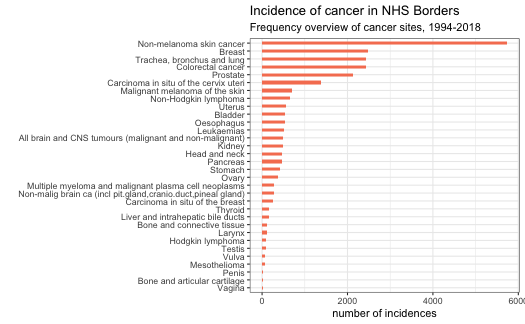

What is the Crude rate? - is calculated by dividing the number of new cancers observed during a given time period by the corresponding number of people in the population at risk - in our cancer case, the result is expressed as an annual rate per 100,000 persons at risk.

What is the European age-standardised rate (EASR)? - proportion of total population in each five year age class (age group 0-4 8k, 5-9 7k,…, 85 and over 1k, total = 100k) - the rates are calculated by applying the age-specific rates for the location being studied to a theoretical European standard population, expressed per 100,000 persons per year - (World age-standardised rate (WASR))

What is the Standardised Incidence Ratio (SIR)?  
- tells us if the number of observed cancer cases in a particular geographic area is higher or lower than expected - the SIR is obtained by dividing the observed number of cases of cancer by the “expected” number of cases

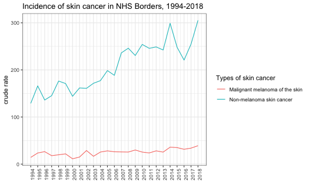

| cancer_site | total |
| --- | --- |
| Non-melanoma skin cancer | 5741 |
| Breast | 2483 |
| Trachea, bronchus and lung | 2441 |
| Colorectal cancer | 2436 |
| Prostate | 2119 |
| Carcinoma in situ of the cervix uteri | 1386 |

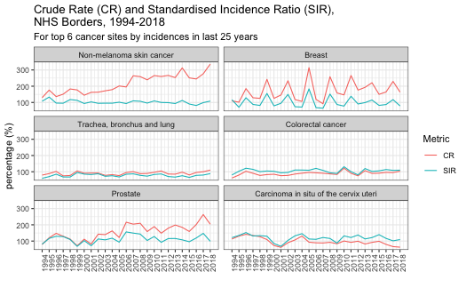

| cancer_site | SIR_avg_2013_2018 |
| --- | --- |
| Thyroid | 227.4784 |
| Hodgkin lymphoma | 195.9399 |
| Bone and articular cartilage | 187.9386 |
| Multiple myeloma and malignant plasma cell neoplasms | 173.2608 |
| Non-Hodgkin lymphoma | 160.5566 |
| Malignant melanoma of the skin | 147.4512 |

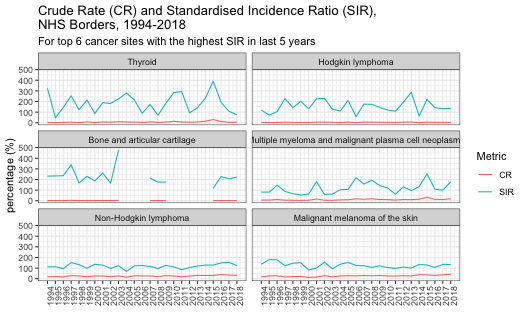

model prediction